# Regression Assignment

### **Model Selection**

#### Summary

```r
models <- list(full_model, MLR_2, MLR_3, MLR_4, MLR_5, stepwise_model, back_red_model)
models_names <- c("Model 1 (Full model)", "Model 2", "Model 3", "Model 4",
                  "Model 5", "Model 6 (Stepwise model)", "Model 7 (Backward Reduction)")

results <- data.frame()

for(i in 1:length(models)) {
  summary_model <- summary(models[[i]])
  r_squared <- summary_model$r.squared
  adj_r_squared <- summary_model$adj.r.squared
  aic <- AIC(models[[i]])
  bic <- BIC(models[[i]])
  cp <- olsrr::ols_mallows_cp(models[[i]], full_model)
  num_params <- length(coefficients(models[[i]]))

  model_results <- data.frame(
    Model = paste(models_names[i]),
    p = num_params,
    R_Squared = r_squared,
    Adj_R_Squared = adj_r_squared,
    AIC = aic,
    BIC = bic,
    CP = cp
  )

  results <- rbind(results, model_results)
}

results %>%
  regulartable() %>%
  bold(part = "header") %>%
  fontsize(part = "header", size = 9.1) %>%
  fontsize(size = 9.5) %>%
  fontsize(j = "Model", size = 8) %>%
  autofit()
```

| Model | p | R_Squared | Adj_R_Squared | AIC | BIC | CP |
| --- | --- | --- | --- | --- | --- | --- |
| Model 1 (Full model) | 8 | 0.7842528 | 0.7740486 | 253.8925 | 281.3412 | 8.000000 |
| Model 2 | 7 | 0.7801992 | 0.7713481 | 254.7964 | 279.1953 | 8.780767 |
| Model 3 | 6 | 0.7768448 | 0.7694063 | 255.1591 | 276.5081 | 9.081804 |
| Model 4 | 5 | 0.7709323 | 0.7648643 | 257.2385 | 275.5377 | 11.137711 |
| Model 5 | 4 | 0.7263250 | 0.7209235 | 282.9946 | 298.2439 | 39.737813 |
| Model 6 (Stepwise model) | 7 | 0.7827773 | 0.7740300 | 252.9558 | 277.3547 | 7.012228 |
| Model 7 (Backward Reduction) | 6 | 0.7777287 | 0.7703197 | 254.5400 | 275.8890 | 8.475468 |

Based on the table above, Model 6 (Stepwise model) has been determined to be the best model. Here’s an explanation:

**Summary:**

Model 6 (Stepwise model) is chosen as the best model because it strikes a balance between model complexity and goodness of fit. It has:

- The second-highest R-squared and Adjusted R-Squared value, indicating good explanatory power.
- The lowest AIC, suggesting the best fit among the models while considering the number of predictors.
- A competitive BIC value, indicating a good balance between model fit and complexity.
- A Mallows’ Cp value close to p, indicating it is relatively unbiased with an appropriate number of predictors.

### **Best Model**

#### Summary

```r
summary(stepwise_model)
```

```
##
## Call:
## lm(formula = Score ~ GDP + Europe + SS + HLE + FTMLC + POC, data = data_2019)
##
## Residuals:
##      Min       1Q   Median       3Q      Max
## -1.80567 -0.33906  0.04092  0.36154  1.13495
##
## Coefficients:
##             Estimate Std. Error t value Pr(>|t|)
## (Intercept)   1.9548     0.2011   9.720  < 2e-16 ***
## GDP           0.7104     0.2152   3.302  0.00120 **
## Europe        0.2163     0.1162   1.861  0.06473 .
## SS            1.0478     0.2379   4.404 2.01e-05 ***
## HLE           0.9737     0.3370   2.889  0.00444 **
## FTMLC         1.6949     0.3737   4.535 1.18e-05 ***
## POC           1.0469     0.5190   2.017  0.04547 *
## ---
## Signif. codes:  0 '***' 0.001 '**' 0.01 '*' 0.05 '.' 0.1 ' ' 1
##
## Residual standard error: 0.5291 on 149 degrees of freedom
## Multiple R-squared:  0.7828, Adjusted R-squared:  0.774
## F-statistic: 89.49 on 6 and 149 DF,  p-value: < 2.2e-16
```

```r
summary(stepwise_model)$coefficients[, "Estimate"]
```

```
## (Intercept)         GDP      Europe          SS         HLE       FTMLC
##   1.9548117   0.7103511   0.2162832   1.0477616   0.9736907   1.6948593
##         POC
##   1.0469120
```

**Least square regression line equation:**

$Score=1.9548+0.7104\space GDP+0.2163\space Europe+1.0478\space SS+0.9737\space HLE+1.6949\space FTMLC+1.0469\space POC$

**Interpretation for estimated coefficients:**

- **Intercept,** $\beta_0$: On average, the model predicts the score will be 1.9548 when all other predictors (GDP, Europe, SS, HLE, FTMLC, and POC) are zero. This represents the baseline score.
- **Slope,** $\beta_1$ (GDP): Given that SS, HLE, FTMLC, and POC are held constant, the model predicts that the score will increase, on average, by 0.7104 for each one-unit increase in GDP per capita.
- **Slope,** $\beta_2$ (Europe): Given that GDP, SS, HLE, FTMLC, and POC are held constant, the model predicts that the score will increase, on average, by 0.2163 for each one-unit increase in the Europe variable.
- **Slope,** $β_3$ (SS), $β_4$ (HLE), $β_5$ (FTMLC), and $β6$ (POC): Similary, the coefficients for these variables would interpret the average increase in the score for each unit increase in these variables, holding all other variables constant.

**Interpretation for Coefficient of determination**

**R-squared:** 78.28% of the variation in $Score$ can be explained by variation in $GDP$, $Europe$, $SS$, $HLE$, $FTMLC$,and $POC$.

#### Research Support

We have conducted a comprehensive study to examine and validate the relationship between the factors included in our best model and the response variable, Happiness Score. This analysis was undertaken to ensure the effectiveness of our chosen model in accurately predicting happiness scores based on these factors. Our findings provide robust support for the predictive capabilities of our model.

*Least square regression line equation:*

$Score=1.9548+0.7104\space GDP+0.2163\space Europe+1.0478\space SS+0.9737\space HLE+1.6949\space FTMLC+1.0469\space POC$

**Why remove the “Generosity” variable?**

Based on our analysis, the generosity factor is excluded from the best model. This is due to several reasons:

1. Changes in happiness were driven by the commitment to be generous, rather than the amount spent. This suggests the act of committing to be generous impacts happiness more than the actual level of generosity.
2. Brain regions involved in empathy and social cognition play a significant role in achieving happiness through generous behaviour. These regions must override selfish motives, implying that intention and commitment are more important than the actual act. (Park, S. et al., 2017).
3. The study also confirms previous findings by Dunn et al., who reported that the amount of money spent on others is indirectly related to happiness, strengthening our analysis that the generosity variable is not a significant predictor of happiness.

**Correlation of *Economic Growth (GDP)* and *Happiness (Score)***

- We then continue to discuss the correlation of the factors which should be included into the best model. First, multiple studies have demonstrated a significant correlation between economic growth and happiness. Data from the World Values Survey reveal that as income increases, happiness also rises within and across the countries over time (Ortiz-Ospina & Roser, 2024). An increase in income improves economic stability, allowing individuals to meet their basic needs such as food, shelter, and healthcare and reduce economic burdens, thus individuals tend to be happier. GDP per capita is a key indicator that measures the average economic output per person and reflects the overall economic well-being of a country. Higher GDP per capita often corresponds to better living standards, greater economic stability, and lower unemployment rates, which positively impact happiness (Helliwell, J.F. et al.,2020). This is supported by another study, as GDP per capita increases, there is a positive, statistically significant correlation with a slight increase in happiness (Stevenson, 2021). Additionally, based on our data for happiness index, the higher-ranked countries have considerably consistently high GDP per Capita with little variation within these countries.

**Correlation of *Region or Country (Europe)* and *Happiness (Score)***

- Moreover, the correlation between region or country and happiness is multifaced. Recent data show that European countries consistently achieve high happiness scores, with Finland, Denmark, Iceland, Switzerland, and the Netherlands at the top. In contrast, outside of Europe, there are significant variations; countries in central Sub-Saharan Africa, such as Afghanistan and South Sudan, tend to have lower happiness scores (Ortiz-Ospina & Roser, 2024).

**Correlation of *Social Support (SS)* and *Happiness (Score)***

- Aristotle was the first to acknowledge humans as social animals. This means humans live and conduct activities in social relationships such as families and friends. Several studies have proven that having supportive relationships contributes to our psychological well-being. These relationships prevent loneliness by providing a sense of belonging. Besides, they also boost our feeling of self-worth and our belief that we are valuable. A supportive social network also ensures security and offers advice, guidance, and motivation when required. A Harvard study called Very Happy People found that there was a 0.7 correlation between social support and happiness (Social Connections and Happiness, n.d.). Thus, the correlation between social support and happiness is clear. Strong social connections fulfil fundamental emotional and psychological needs which contribute to higher levels of happiness, lower levels of stress, and better mental health outcomes.

**Correlation of *Health life expectancy (HLE)* and *Happiness (Score)***

- Healthy life expectancy, defined as the average number of years a person is expected to live in good health, has also proven strongly correlated with happiness. The World Health Organization’s (WHO) data analyzed in World Happiness Report 2020, which includes data from 2019, shows that countries with higher healthy life expectancy reported higher levels of happiness. (Helliwell et al., 2020). A group of researchers’ study from Singapore also supports this connection. They found that happier people generally have lower mortality rates. They tend to live longer even after adjusting for various sociodemographic, physical, and psychological health factors. Happiness is also linked to lower rates of chronic diseases, which in turn extends life expectancy. (Song, C.F. et al., 2023). In summary, both sources highlight the positive influence of happiness on longevity, suggesting the high relationship between healthy life expectancy and happiness.

**Correlation of *Freedom to make life choices (FTMLC)* and *Happiness (Score)***

- An article from City Journal discusses how perceived freedom is strongly correlated with happiness. According to the General Social Survey, individuals who feel completely or very free are more likely to describe themselves as very happy compared to those who feel moderately or less free. This correlation remains even after controlling for variables such as income, education, and family status (Brooks, 2008). Moreover, the article also mentioned a 2003 study of German senior citizens in which the researcher found that a low level of perceived personal freedom strongly predicted depression. The findings suggest that freedom to make life choices has an impact on happiness, emphasizing its importance in enhancing life satisfaction.

**Correlation of *Perceptions of corruption (POC)* and *Happiness (Score)***

- A cross-national study of 126 countries revealed that a 10-point increase in corruption resulted in a 0.23-point decline in the national average of subjective well-being (Li, Q., & An, L., 2020). Thus, the research highlights a strong connection between perceptions of corruption and happiness, suggesting that people’s life satisfaction and overall happiness decline as they perceive more corruption. When additional factors are taken into consideration, this relationship remains robust. This reveals that corruption has an adverse impact on subjective well-being. As the corruption level rises, trust among citizens declines, leading to reduced happiness levels.

#### VIF

```r
vif_values <- vif(stepwise_model)

vif_df <- data.frame(t(vif_values))

vif_table <- flextable(vif_df)
vif_table <- set_caption(vif_table, "Variance Inflation Factor (VIF)")
vif_table
```

Variance Inflation Factor (VIF)

| GDP | Europe | SS | HLE | FTMLC | POC |
| --- | --- | --- | --- | --- | --- |
| 4.0672 | 1.435018 | 2.804403 | 3.685663 | 1.587624 | 1.332647 |

##### Barplot

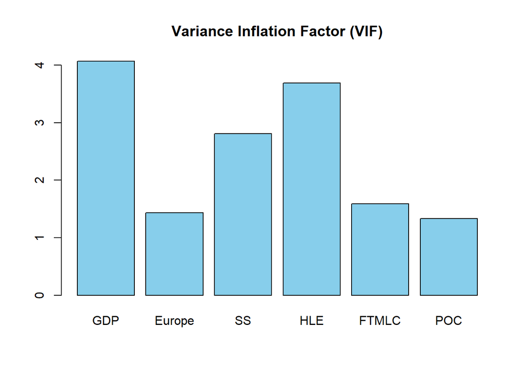

```r
barplot(vif_values, col = "skyblue", main = "Variance Inflation Factor (VIF)")
```

In general, a VIF value of 1 indicates no multicollinearity, a value between 1 and 5 suggests moderate multicollinearity, and a value greater than 5 indicates high multicollinearity.

- None of the variables have a VIF above 5, so there are no severe multicollinearity issues.
- The variables with the highest VIFs are **GDP**, **HLE** and **SS**, but their values are still within a range that typically does not warrant major concern.
- **Europe**, **FTMLC**, and **POC** have low VIF values, indicating they are not strongly correlated with other predictors in the model.

#### Confidence Interval

```r
confint(stepwise_model, level = 0.90)
```

```
##                    5 %      95 %
## (Intercept) 1.62194676 2.2876765
## GDP         0.35424672 1.0664554
## Europe      0.02391413 0.4086522
## SS          0.65402254 1.4415006
## HLE         0.41591789 1.5314634
## FTMLC       1.07627774 2.3134408
## POC         0.18791951 1.9059044
```

#### Prediction Modelling

```r
new_df3 <- data.frame(
  Europe = c(0, 0, 1),
  GDP = c(0.931, 1.894, 1.452),
  SS = c(0.592, 0.782, 1.410),
  HLE = c(0.826, 1.109, 0.902),
  FTMLC = c(0.595, 0.423, 0.308),
  Gen = c(0.151, 0.284, 0.385),
  POC = c(0.395, 0.075, 0.298)
)

predict(stepwise_model, new_df3)
```

```
##        1        2        3
## 5.462663 5.994833 6.392134
```

- **Observation 1:** Given the input features for the first observation, the model predicts a score of approximately 5.463.
- **Observation 2:** For the second observation, with its set of predictor values, the predicted score is approximately 5.995.
- **Observation 3:** The third observation, based on its predictors, is predicted to have a score of approximately 6.392.

#### CI on mean response

```r
predict(stepwise_model, new_df3,
        interval = "confidence",
        level=0.95)
```

```
##        fit      lwr      upr
## 1 5.462663 5.059433 5.865894
## 2 5.994833 5.476129 6.513536
## 3 6.392134 6.113675 6.670593
```

- For **group 1**, the estimated mean response (`fit`) is 5.462663. The lower bound (`lwr`) of the 95% confidence interval is 5.059433, and the upper bound (`upr`) is 5.865894.
- For **group 2**, the estimated mean response is 5.994833, with a 95% confidence interval ranging from 5.476129 to 6.513536.
- For **group 3**, the estimated mean response is 6.392134, with a 95% confidence interval ranging from 6.113675 to 6.670593.

#### PI for future observation

```r
predict(stepwise_model, new_df3,
        interval = "prediction",
        level=0.95)
```

```
##        fit      lwr      upr
## 1 5.462663 4.342024 6.583302
## 2 5.994833 4.827661 7.162005
## 3 6.392134 5.310110 7.474158
```

- For **group 1**, the estimated mean response (`fit`) is 5.462663. The lower bound (`lwr`) of the 95% prediction interval is 4.342024, and the upper bound (`upr`) is 6.583302.
- For **group 2**, the estimated mean response is 5.994833, with a 95% prediction interval ranging from 4.827661 to 7.162005.
- For **group 3**, the estimated mean response is 6.392134, with a 95% prediction interval ranging from 5.310110 to 7.474158.

#### ANOVA

```r
anova(stepwise_model)
```

```
## Analysis of Variance Table
##
## Response: Score
##            Df  Sum Sq Mean Sq  F value    Pr(>F)
## GDP         1 121.040 121.040 432.3086 < 2.2e-16 ***
## Europe      1   1.495   1.495   5.3408  0.022204 *
## SS          1  13.131  13.131  46.8982 1.830e-10 ***
## HLE         1   3.979   3.979  14.2112  0.000235 ***
## FTMLC       1   9.549   9.549  34.1039 3.156e-08 ***
## POC         1   1.139   1.139   4.0692  0.045467 *
## Residuals 149  41.718   0.280
## ---
## Signif. codes:  0 '***' 0.001 '**' 0.01 '*' 0.05 '.' 0.1 ' ' 1
```

**Summary**

- **GDP:** Extremely significant predictor of Score.
- **Europe, SS, HLE, FTMLC, and POC:** All significantly predict Score, with varying levels of significance.
- The model explains a substantial amount of the variance in the response variable “Score,” as indicated by the significant F values and low p-values for all predictors.

#### Residuals Analysis

##### Summary

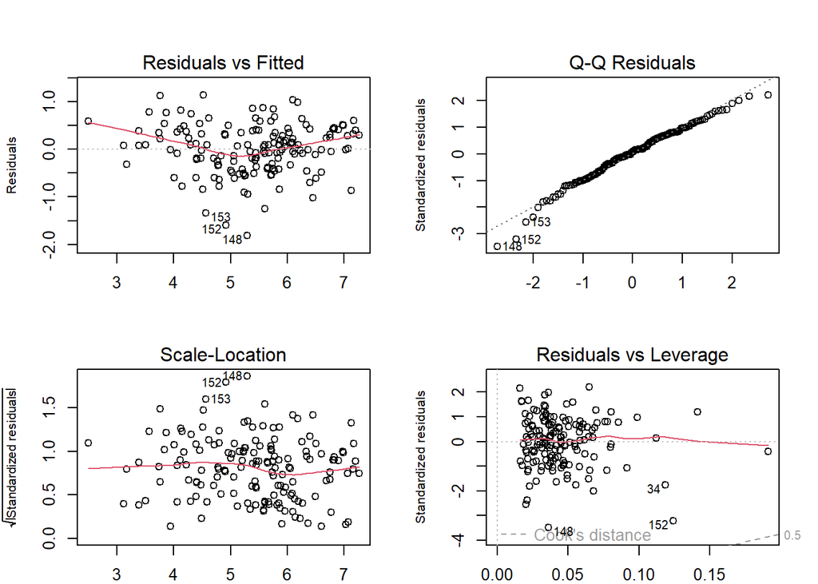

```r
par(mfrow = c(2,2),mar =c(2,4,4,2), cex.lab = 0.8)
plot(stepwise_model)
```

##### Standardized residuals

```r
# Standardized residuals
sta_res_stepwise <- rstandard(stepwise_model)
dfstares_stepwise <- data.frame(sta_res_stepwise)
dfstares_stepwise$x <- seq(1:nrow(data_2019))

fittedvalue <- fitted(stepwise_model)
```

##### Studentized residuals

```r
# Studentized residuals
stu_res_stepwise <- studres(stepwise_model)
dfstures_stepwise <- data.frame(stu_res_stepwise)
dfstures_stepwise$x <- seq(1:nrow(data_2019))
```

##### Histogram for standardized & studentized residuals

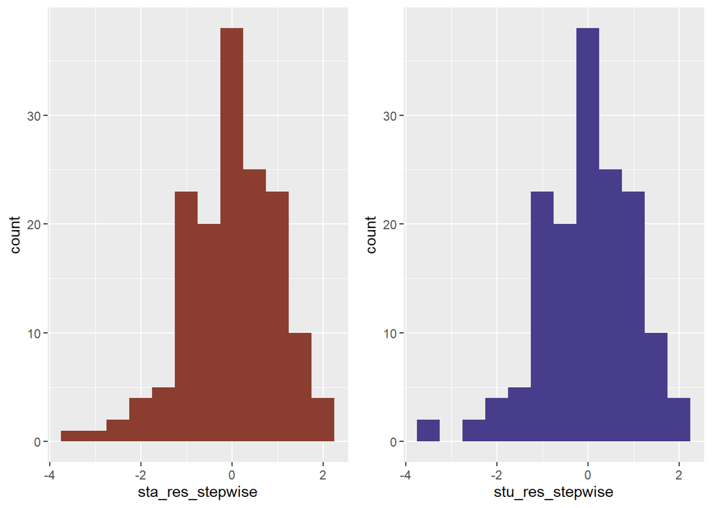

```r
sta_hist2 <- ggplot(dfstares_stepwise, aes(x = sta_res_stepwise)) + geom_histogram(binwidth = 0.5, fill = "coral4")


stu_hist2 <- ggplot(dfstures_stepwise, aes(x = stu_res_stepwise)) + geom_histogram(binwidth = 0.5, fill = "darkslateblue")

ggarrange(sta_hist2, stu_hist2, ncol = 2, nrow = 1)
```

1. **Shape and Center**:
   - Both histograms are bell-shaped and peak at zero, indicating that most residuals are centered around zero. This suggests a generally good fit of the model to the data.
2. **Skewness**:
   - Both histograms exhibit a slight left skew, implying that there are more negative residuals than positive ones. This skewness points to the presence of negative outliers that might be affecting the model.
3. **Spread**:
   - Both the standardized and studentized residuals range from approximately -4 to +2, with the majority of residuals falling between -2 and +2. This indicates similar variability in the residuals around the fitted values.
4. **Normality Assumption**:
   - The bell-shaped distribution in both histograms supports the normality assumption of residuals, which is crucial for the validity of linear regression models.

##### Scatterplots of standardized & studentized residuals

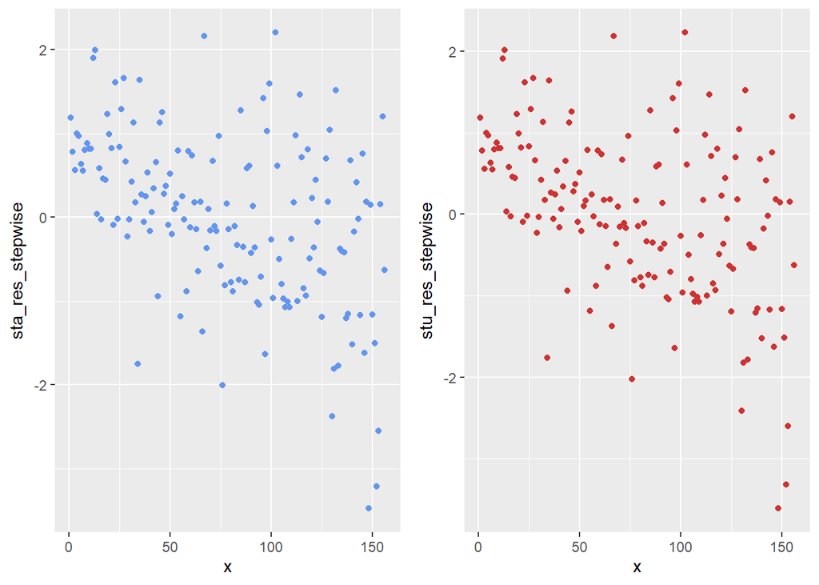

```r
#standardized residuals
sta_plot2 <- ggplot() + geom_point(data = dfstares_stepwise, aes(x = x, y = sta_res_stepwise), color = "cornflowerblue")

# Studentized residuals
stu_plot2 <- ggplot() + geom_point(data = dfstures_stepwise, aes(x = x, y = stu_res_stepwise), color = "brown3")

ggarrange(sta_plot2, stu_plot2, ncol = 2, nrow = 1)
```

1. **Pattern in Residuals**
   - There is a noticeable pattern where residuals are higher for lower values of $x$ and decrease as $x$ increases, indicating potential non-linearity that the linear model is not capturing well.
2. **Heteroscedasticity**
   - The residuals’ spread changes with $x$, being more tightly clustered in the middle range (50 to 100) and more spread out at the edges. This suggests heteroscedasticity, violating the linear regression assumption of constant variance, which could impact regression estimates’ efficiency and hypothesis tests’ validity.
3. **Outliers**
   - Observations greater than 2 or less than -2 are considered potential outliers. There are a few points, especially around $x = 150$, where residuals are far from zero, indicating potential outliers that might disproportionately affect the regression model.
4. **Residual Centering**
   - The residuals generally center around zero, indicating no consistent bias in the model’s predictions. This is a good sign, showing that the model does not systematically over- or under-predict the response variable.

As studentized residuals are adjusted for the influence of each data point, the observations on the scatterplot of the studentized residuals are more sensitive.

# **Conclusion**

Our comprehensive regression analysis on the 2019 happiness score data from Kaggle has yielded significant insights into the factors influencing global happiness scores. By analyzing factors such as GDP per capita, social support, healthy life expectancy, freedom to make life choices, generosity, perceptions of corruption, and the categorical variable Region_europe (European vs. non-European), we have successfully identified the optimal combination of variables that best predict happiness scores and developed a robust model for determining happiness.

**Key findings include:**

1. **Simple Linear Regression:**
   - *Most Influential Variable*: GDP per capita emerged as the most influential factor, exhibiting the highest correlation with happiness scores.
   - *Model Development*: A simple linear regression model was developed between GDP per capita and happiness scores.
   - *Validation*: This model was validated through various regression analyses, including scatterplots, prediction modeling, ANOVA tables, and residual analysis. The results confirmed the robustness and validity of the model, reinforcing the significant role of GDP per capita in predicting happiness scores.
2. **Multiple Linear Regression Model:**
   - *Comprehensive Analysis*: A multiple linear regression model incorporating all relevant variables was created.
   - *Validation*: This comprehensive model underwent rigorous validation through regression analyses.
3. **Variable & Model Selection**:
   - *Selection Techniques*: Several model selection techniques were employed to identify and refine the best-fit model., including:
     - Adjusted R-squared
     - Akaike Information Criterion (AIC)
     - Bayesian Information Criterion (BIC)
     - Stepwise, Backward Stepwise, and Forward Stepwise Regression
     - Backward Reduction method using the F-test
4. **Best-fit Model (Model 6):**
   - *Stepwise Selection Method*: Model 6, derived using the stepwise selection method, was identified as the optimal model.
   - *Balance of Complexity and Fit*: This model optimally balances model complexity and goodness of fit, making it the most effective model for predicting happiness scores.
   - *Variable Inclusion*: Notably, Model 6 excludes the variable ‘generosity’ but includes all other significant variables, highlighting the relative importance of these factors in influencing happiness scores.
   - *Robustness and Accuracy*: A series of regression analyses were conducted on this multiple linear regression model to ensure its robustness and accuracy.

## **Recommendations**

We have made some recommendations on improving happiness based on our best model. These include:

1. **Enhance GDP per capita**
   - Governments play a pivotal role in enhancing the quality of life and creating environments that support the well-being and happiness of citizens. Our analysis found that GDP per capita is the most significant variable influencing the Happiness Score, with a correlation of 0.79. Therefore, governments could focus on policies that promote economic growth and increase GDP per capita. This could include investing in education, infrastructure, and technology to boost productivity and economic well-being. In terms of policy implications, policymakers should prioritize happiness alongside economic growth as a core principle of government policy. Evidence supports the approach of countries like Scotland, New Zealand, and Iceland, which emphasize citizen well-being within their national development strategies. Policymakers should aim to enhance happiness through initiatives that improve the quality of life, offer robust social support, promote work-life balance, and invest in education and healthcare (Lee & Goh, 2023).
2. **Strengthen Social support**
   - To increase happiness, we should prioritize strengthening social support. Based on our analysis, social support is one of the most important factors influencing happiness scores in the best model. According to HelpGuide.org (2024), good relationships improve overall happiness. To strengthen social support, it is essential to focus on building and nurturing robust social networks within communities. Encouraging activities that foster community connections, such as social events, support groups, and collective projects, can enhance social support. Joining clubs related to our interests, participating in team sports, and engaging in volunteer work are other effective ways to connect with others. Being part of a group provides a sense of belonging and support, which is beneficial to mental health (Cherry, 2023). Regular interaction with others helps individuals experience less loneliness and isolation, lowering the likelihood of depression and anxiety. Additionally, volunteering provides a sense of meaning and accomplishment, further enhancing life satisfaction and contributing to community growth (Robinson, 2024).

By focusing on these key areas, policymakers can create an environment that supports the well-being and happiness of citizens.